# Expected Threat (xT) STAT 479

Mason Langer, Rohan Ahuja, Hazim bin Mohd Izani

2025-10-09

```r
suppressPackageStartupMessages({
  library(hoopR)
  library(dplyr)
  library(tidyr)
  library(stringr)
  library(janitor)
  library(ggplot2)
})

# small helper fx
`%||%` <- function(a, b) if (is.null(a) || length(a) == 0 || (is.character(a) && a == "")) b else a
nz <- function(x) ifelse(is.na(x), 0, x)
first2 <- function(x) { w <- which(!is.na(x)); if (length(w)) x[w[1]] else NA }
last2  <- function(x) { w <- which(!is.na(x)); if (length(w)) x[w[length(w)]] else NA }

# mirror ESPN full-court x (0..100) into single attacking half (0..50)
to_halfcourt <- function(x, y) tibble(x = ifelse(x > 50, 100 - x, x), y = y)
```

## Data & preprocessing

We load the full season PBP from hoopR, normalize the columns (scores, team ids, coordinates), and sort by `game_id` and `game_play_number` We normalize season play-by-play (one row per event)

```r
cand <- hoopR::most_recent_nba_season()
candidate_seasons <- c(cand - 1L, cand)  # eg try 2024 first, then 2025 -> this is to get the latest season

# returns NULL if the call errors or returns an empty frame. this avoids hard stops if a season isnt available
load_one <- function(s) {
  out <- try(hoopR::load_nba_pbp(seasons = s) %>% janitor::clean_names(), silent = TRUE)
  if (inherits(out, "try-error")) return(NULL)
  if (!is.data.frame(out) || nrow(out) == 0) return(NULL)
  out
}

# keeps first non empty results as pbp_raw
pbp_raw <- NULL; season_used <- NA_integer_
for (s in candidate_seasons) {
  tmp <- load_one(s)
  if (!is.null(tmp)) { pbp_raw <- tmp; season_used <- s; break }
}
stopifnot(!is.null(pbp_raw), nrow(pbp_raw) > 0) #just ensures we load something

# Normalization helpers (no mixedtype coalesce)
safe_coalesce_chr <- function(df, candidates) {
  v <- rep(NA_character_, nrow(df))
  for (nm in candidates) {
    if (nm %in% names(df)) {
      src <- df[[nm]]
      csrc <- as.character(src)
      csrc[is.na(src)] <- NA_character_
      v <- ifelse(is.na(v) | v == "", csrc, v)
    }
  }
  v
}

# Build normalized vectors
clock_vec <- safe_coalesce_chr(pbp_raw, c("clock_display_value","clock"))
text_vec  <- safe_coalesce_chr(pbp_raw, c("text","type_text","play_text","description"))

coord_x <- if ("coordinate_x" %in% names(pbp_raw)) suppressWarnings(as.numeric(pbp_raw$coordinate_x)) else rep(NA_real_, nrow(pbp_raw))
coord_y <- if ("coordinate_y" %in% names(pbp_raw)) suppressWarnings(as.numeric(pbp_raw$coordinate_y)) else rep(NA_real_, nrow(pbp_raw))

score_value_i <- if ("score_value" %in% names(pbp_raw)) suppressWarnings(as.integer(pbp_raw$score_value)) else rep(NA_integer_, nrow(pbp_raw))
scoring_play_i <- if ("scoring_play" %in% names(pbp_raw)) suppressWarnings(as.integer(pbp_raw$scoring_play)) else rep(NA_integer_, nrow(pbp_raw))
game_play_number_i  <- if ("game_play_number" %in% names(pbp_raw)) pbp_raw$game_play_number else seq_len(nrow(pbp_raw))
team_id_chr <- if ("team_id" %in% names(pbp_raw)) as.character(pbp_raw$team_id) else rep(NA_character_, nrow(pbp_raw))
home_score_i <- if ("home_score" %in% names(pbp_raw)) pbp_raw$home_score else rep(NA_integer_, nrow(pbp_raw))
away_score_i <- if ("away_score" %in% names(pbp_raw)) pbp_raw$away_score else rep(NA_integer_, nrow(pbp_raw))

# Final normalized PBP table for the season
pbp <- pbp_raw %>%
  dplyr::mutate(
    game_id = as.character(game_id),
    period = pbp_raw$period,
    clock = clock_vec,
    text = text_vec,
    team_id = team_id_chr,
    home_score = home_score_i,
    away_score = away_score_i,
    coordinate_x = coord_x,
    coordinate_y = coord_y,
    score_value = score_value_i,
    scoring_play = scoring_play_i,
    game_play_number = game_play_number_i
  ) %>%
  dplyr::select(game_id, period, clock, text, team_id, home_score, away_score,
                coordinate_x, coordinate_y, score_value, scoring_play, game_play_number) %>%
  dplyr::arrange(game_id, game_play_number)

# Sanity check
list(
  season_used= season_used,
  total_rows = nrow(pbp),
  unique_games = dplyr::n_distinct(pbp$game_id),
  rows_with_coords = sum(!is.na(pbp$coordinate_x) & !is.na(pbp$coordinate_y))
)
```

```
## $season_used
## [1] 2025
##
## $total_rows
## [1] 624997
##
## $unique_games
## [1] 1324
##
## $rows_with_coords
## [1] 624997
```

### Shot value surface (EP per FGA) with Laplace smoothing

We mirror to one attacking half, bin shots into a 20×14 grid, and compute EP/FGA with Laplace smoothing toward the league-wide prior.

```r
# Filter to field-goal attempts with coordinates (exclude free throws)
shots <- pbp %>%
  dplyr::filter(!is.na(coordinate_x), !is.na(coordinate_y)) %>%
  dplyr::mutate(
    tlow = tolower(ifelse(is.na(text), "", as.character(text)))
  ) %>%
  dplyr::filter(
    stringr::str_detect(tlow, "makes|misses"),
    !stringr::str_detect(tlow, "free throw")
  ) %>%
  dplyr::mutate(
    is_three = stringr::str_detect(tlow, "3[- ]?pt|three"),
    points_attempt = dplyr::if_else(is_three, 3L, 2L),
    points_scored = nz(dplyr::if_else(scoring_play == 1L, score_value, 0L))
  )

# Mirror full court to a single attacking half and bin into a coarse grid
GRID_NX <- 20; GRID_NY <- 14
hc <- to_halfcourt(shots$coordinate_x, shots$coordinate_y)

shots <- dplyr::bind_cols(shots, hc) %>%
  dplyr::mutate(
    gx = cut(x, breaks = seq(0, 50, length.out = GRID_NX + 1), labels = FALSE, include.lowest = TRUE),
    gy = cut(y, breaks = seq(0, 50, length.out = GRID_NY + 1), labels = FALSE, include.lowest = TRUE)
  ) %>%
  dplyr::filter(!is.na(gx), !is.na(gy))

# Global expected points per FGA (baseline prior)
global_ep_fga <- sum(shots$points_scored, na.rm = TRUE) / nrow(shots)

# Laplace smoothing toward the global prior
LAPLACE <- 150

cell <- shots %>%
  dplyr::group_by(gx, gy) %>%
  dplyr::summarise(
    fga = dplyr::n(),
    pts = sum(points_scored),
    ep_fga_raw = pts / fga,
    .groups = "drop"
  ) %>%
  dplyr::mutate(
    ep_fga = (pts + LAPLACE * global_ep_fga) / (fga + LAPLACE)
  )

# Quick report and heatmap
list(
  n_shots = nrow(shots),
  grid_cells = nrow(cell),
  global_ep_fga = round(global_ep_fga, 3)
)
```

```
## $n_shots
## [1] 60940
##
## $grid_cells
## [1] 128
##
## $global_ep_fga
## [1] 1.18
```

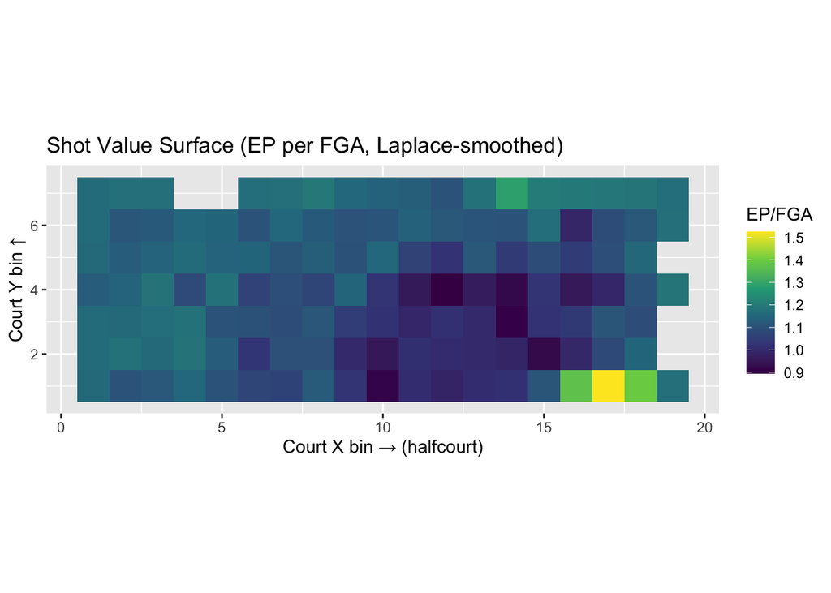

```r
cell %>%
  ggplot2::ggplot(ggplot2::aes(gx, gy, fill = ep_fga)) +
  ggplot2::geom_tile() +
  ggplot2::coord_fixed() +
  ggplot2::scale_fill_viridis_c(name = "EP/FGA") +
  ggplot2::labs(
    title = "Shot Value Surface (EP per FGA, Laplace-smoothed)",
    x = "Court X bin → (halfcourt)",
    y = "Court Y bin ↑"
  )
```

*Figure.* Laplace-smoothed shot value (EP/FGA). Labels approximate halfcourt zones -> brighter = higher value.

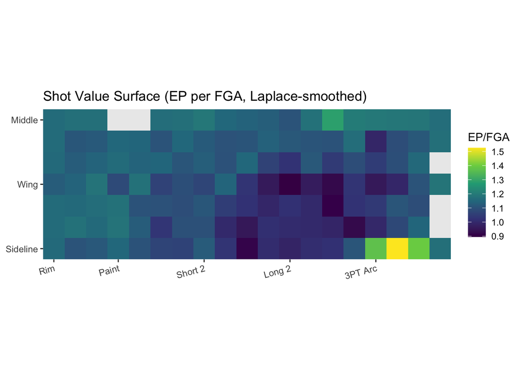

```r
# Nice axis labels for halfcourt grid
x_breaks <- c(1, 4, 8, 12, 16, 20)
x_labs <- c("Rim", "Paint", "Short 2", "Long 2", "3PT Arc", "Midcourt")

y_breaks <- c(1, 4, 7, 10, 14)
y_labs <- c("Sideline", "Wing", "Middle", "Wing", "Sideline") # just makes the graph more understandable and intuitive

cell %>%
  ggplot2::ggplot(ggplot2::aes(gx, gy, fill = ep_fga)) +
  ggplot2::geom_tile() +
  ggplot2::coord_fixed() +
  ggplot2::scale_fill_viridis_c(name = "EP/FGA") +
  ggplot2::scale_x_continuous(breaks = x_breaks, labels = x_labs, expand = c(0, 0)) +
  ggplot2::scale_y_continuous(breaks = y_breaks, labels = y_labs, expand = c(0, 0)) +
  ggplot2::labs(
    title = "Shot Value Surface (EP per FGA, Laplace-smoothed)",
    x = NULL, y = NULL
  ) +
  ggplot2::theme(
    axis.text.x = ggplot2::element_text(angle = 15, hjust = 1),
    panel.grid = ggplot2::element_blank()
  )
```

### Start-context construction (strict prior-shot rule)

We relabel each shot’s start context only from the previous shot in the same game: - **After Opp MAKE (inbound):** previous shot scored and was by the other team.  
- **After Opp MISS (def reb/transition):** previous shot missed and was by the other team.  
- **Same Team (2nd chance):** previous shot missed and was by the same team (offensive rebound).  
- **Start of Game:** first shot of the game.

```r
# Rebuild start context strictly from prior shot team/result
shots_poss <- shots %>%
  dplyr::arrange(game_id, game_play_number) %>%
  dplyr::group_by(game_id) %>%
  dplyr::mutate(
    team_id_shot = as.character(team_id),
    prev_team = dplyr::lag(team_id_shot),
    prev_points = dplyr::lag(points_scored),
    same_team = !is.na(prev_team) & team_id_shot == prev_team,

    start_ctx = dplyr::case_when(
      is.na(prev_team) ~ "Start of Game",
      prev_points > 0 ~ "After Opp MAKE (inbound)", # after a make, possession flips
      prev_points == 0 & same_team ~ "Same Team (2nd chance)", # miss + off. rebound
      prev_points == 0 & !same_team ~ "After Opp MISS (def reb/transition)",  # miss + def. rebound
      TRUE ~ "Unknown"
    ),

    # Possession proxy id: increment when shooting team changes
    poss_id_shot = cumsum(dplyr::row_number() == 1L |
                          team_id_shot != dplyr::lag(team_id_shot, default = first(team_id_shot))),

    points_offense = points_scored
  ) %>%
  dplyr::ungroup()

# Sanity checks
list(
  n_possessions_shot = nrow(shots_poss),
  ppp_shot_only_fg = round(mean(shots_poss$points_offense, na.rm = TRUE), 3)
)
```

```
## $n_possessions_shot
## [1] 60940
##
## $ppp_shot_only_fg
## [1] 1.18
```

```r
shots_poss %>% dplyr::count(start_ctx, sort = TRUE)
```

| start_ctx | n |
| --- | --- |
| After Opp MAKE (inbound) | 30555 |
| Same Team (2nd chance) | 28850 |
| Start of Game | 1324 |
| After Opp MISS (def reb/transition) | 211 |

### EPV at possession start (by context)

We use the previous shot’s result and team to classify the start context (inbound after make, defensive rebound/transition after miss, same-team 2nd chance, start of game) and estimate EPV at the start of each shot-possession.

```r
# count shots per context
ctx_counts <- shots_poss %>%
  dplyr::count(start_ctx, sort = TRUE)
ctx_counts
```

| start_ctx | n |
| --- | --- |
| After Opp MAKE (inbound) | 30555 |
| Same Team (2nd chance) | 28850 |
| Start of Game | 1324 |
| After Opp MISS (def reb/transition) | 211 |

```r
# EPV_start = mean points per shot-possession given the start context
epv_start_ctx <- shots_poss %>%
  dplyr::group_by(start_ctx) %>%
  dplyr::summarise(
    n_poss = dplyr::n(),
    epv_start = mean(points_offense, na.rm = TRUE),
    .groups = "drop"
  ) %>%
  dplyr::arrange(desc(epv_start))
epv_start_ctx
```

| start_ctx | n_poss | epv_start |
| --- | --- | --- |
| Same Team (2nd chance) | 28850 | 1.1883536 |
| Start of Game | 1324 | 1.1850453 |
| After Opp MAKE (inbound) | 30555 | 1.1748323 |
| After Opp MISS (def reb/transition) | 211 | 0.7535545 |

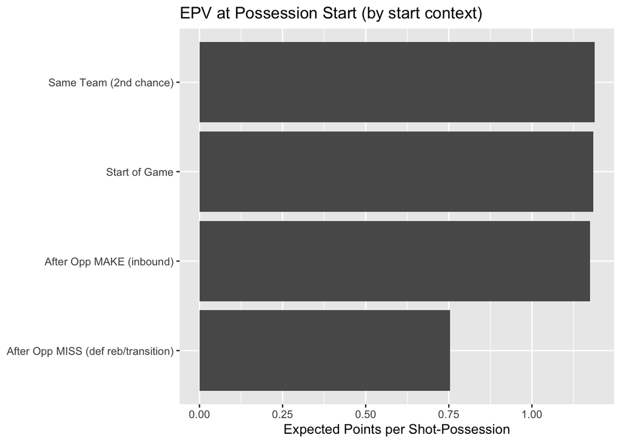

```r
# Quick bar chart
ggplot2::ggplot(epv_start_ctx, ggplot2::aes(reorder(start_ctx, epv_start), epv_start)) +
  ggplot2::geom_col() +
  ggplot2::coord_flip() +
  ggplot2::labs(title = "EPV at Possession Start (by start context)",
                x = NULL, y = "Expected Points per Shot-Possession")
```

### xT-like delta (end shot value − start EPV)

ΔxT measures how much value a possession gained from its start context to the terminal shot location (grid EP/FGA − EPV_start).

```r
# xT-like delta: end shot value − start EPV

# attach end-location value (EP/FGA) from the shot surface onto each shot
shots_poss2 <- shots_poss %>%
  dplyr::left_join(cell %>% dplyr::select(gx, gy, ep_fga), by = c("gx","gy"))

# attach EPV_start from start context
shots_poss2 <- shots_poss2 %>%
  dplyr::left_join(epv_start_ctx %>% dplyr::select(start_ctx, epv_start), by = "start_ctx")

# delta = end shot value − start EPV
shots_poss2 <- shots_poss2 %>%
  dplyr::mutate(xt_delta = ep_fga - epv_start)

# quick sanity checks
sum(is.na(shots_poss2$ep_fga)) # should be 0
```

```
## [1] 0
```

```r
sum(is.na(shots_poss2$epv_start))  # should be 0
```

```
## [1] 0
```

```r
summary(shots_poss2$xt_delta)
```

```
##     Min.  1st Qu.   Median     Mean  3rd Qu.     Max.
## -0.29309 -0.11628 -0.05725  0.02397  0.19804  0.77169
```

```r
# Context leaderboard
xt_by_ctx <- shots_poss2 %>%
  dplyr::group_by(start_ctx) %>%
  dplyr::summarise(
    n = dplyr::n(),
    mean_delta = mean(xt_delta, na.rm = TRUE),
    median_delta = median(xt_delta, na.rm = TRUE),
    .groups = "drop"
  ) %>%
  dplyr::arrange(dplyr::desc(mean_delta))

xt_by_ctx
```

| start_ctx | n | mean_delta | median_delta |
| --- | --- | --- | --- |
| After Opp MISS (def reb/transition) | 211 | 0.40103521 | 0.35683351 |
| Same Team (2nd chance) | 28850 | 0.02691738 | -0.05724646 |
| After Opp MAKE (inbound) | 30555 | 0.02009052 | -0.06299070 |
| Start of Game | 1324 | -0.01097997 | -0.07511649 |

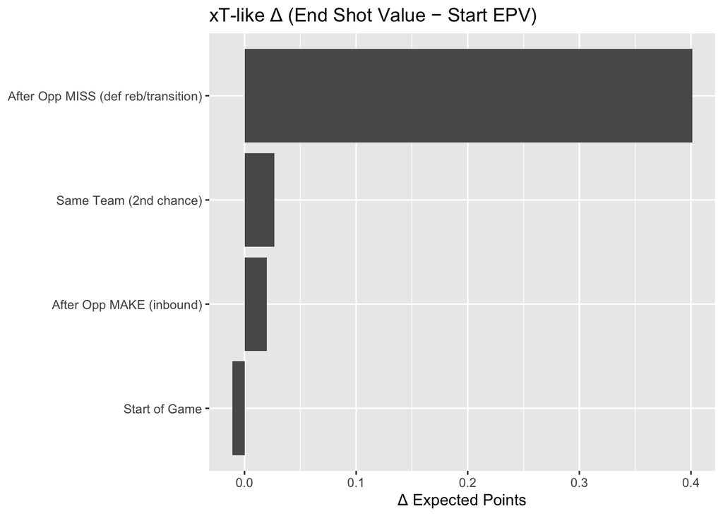

```r
ggplot2::ggplot(xt_by_ctx, ggplot2::aes(reorder(start_ctx, mean_delta), mean_delta)) +
  ggplot2::geom_col() +
  ggplot2::coord_flip() +
  ggplot2::labs(title = "xT-like Δ (End Shot Value − Start EPV)",
                x = NULL, y = "Δ Expected Points")
```

### Player impact (shooter-only)

We credit 100% of ΔxT to the shooter for a first-pass view of impact.

```r
# Extract shooter name to each shot
extract_shooter <- function(s) {
  s <- ifelse(is.na(s), "", s)
  nm <- stringr::str_extract(s, "^[A-Za-z.' -]+(?=\\s+(?:makes|misses))")
  stringr::str_squish(nm)
}

shots_poss2 <- shots_poss2 %>%
  dplyr::mutate(shooter = extract_shooter(text))

# Aggregate ΔxT by player
player_xt <- shots_poss2 %>%
  dplyr::filter(!is.na(shooter) & shooter != "") %>%
  dplyr::group_by(shooter) %>%
  dplyr::summarise(
    shots = dplyr::n(),
    xt_delta_sum = sum(xt_delta, na.rm = TRUE),
    xt_delta_mean = mean(xt_delta, na.rm = TRUE),
    .groups = "drop"
  ) %>%
  dplyr::arrange(dplyr::desc(xt_delta_sum))

# Top 20 by total ΔxT
top20_xt <- player_xt %>% dplyr::slice_head(n = 20)
top20_xt
```

| shooter | shots | xt_delta_sum | xt_delta_mean |
| --- | --- | --- | --- |
| Giannis Antetokounmpo | 513 | 59.89409 | 0.11675262 |
| Rudy Gobert | 211 | 57.10849 | 0.27065637 |
| Jarrett Allen | 219 | 44.61184 | 0.20370704 |
| Jalen Duren | 170 | 39.67566 | 0.23338625 |
| Karl-Anthony Towns | 418 | 37.95871 | 0.09081032 |
| Onyeka Okongwu | 189 | 36.06295 | 0.19080924 |
| Ivica Zubac | 295 | 34.54652 | 0.11710685 |
| Evan Mobley | 263 | 33.00605 | 0.12549831 |
| OG Anunoby | 333 | 32.17079 | 0.09660897 |
| Christian Braun | 265 | 31.35640 | 0.11832605 |

[output cut: 10 more lines]

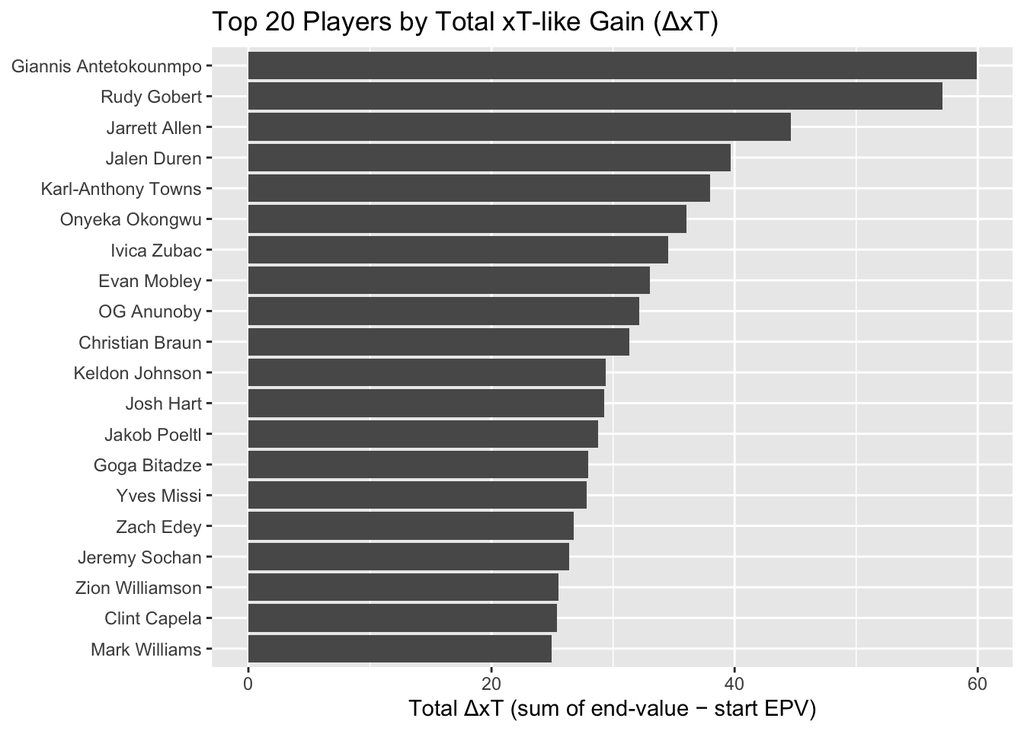

```r
# Plot
ggplot2::ggplot(top20_xt, ggplot2::aes(reorder(shooter, xt_delta_sum), xt_delta_sum)) +
  ggplot2::geom_col() +
  ggplot2::coord_flip() +
  ggplot2::labs(
    title = "Top 20 Players by Total xT-like Gain (ΔxT)",
    x = NULL, y = "Total ΔxT (sum of end-value − start EPV)"
  )
```

#### Player impact with rebound shares (70% shooter / 30% rebounder)

On second-chance and defensive-rebound transitions, we split ΔxT 70/30 between shooter and rebounder.

```r
# helper fx to pull a name from rebound text (common ESPN phrasings)
extract_rebounder <- function(s) {
  s <- ifelse(is.na(s), "", s)
  # "Firstname Lastname offensive/defensive rebound"
  m1 <- stringr::str_extract(s, "^[A-Za-z.' -]+(?=\\s+(?:offensive|defensive) rebound)")
  # "rebound by Firstname Lastname"
  m2 <- stringr::str_extract(s, "(?<=rebound by\\s)[A-Za-z.' -]+")
  nm <- ifelse(!is.na(m1), m1, m2)
  stringr::str_squish(nm)
}

# Build a filled table with the last OFF/DEF rebound seen up to each play
reb_fill <- pbp %>%
  dplyr::mutate(
    tlow = tolower(ifelse(is.na(text), "", text)),
    is_off_reb = stringr::str_detect(tlow, "offensive rebound"),
    is_def_reb = stringr::str_detect(tlow, "defensive rebound"),
    off_order  = dplyr::if_else(is_off_reb, game_play_number, NA_integer_),
    def_order  = dplyr::if_else(is_def_reb, game_play_number, NA_integer_),
    off_name   = dplyr::if_else(is_off_reb, extract_rebounder(text), NA_character_),
    def_name   = dplyr::if_else(is_def_reb, extract_rebounder(text), NA_character_)
  ) %>%
  dplyr::arrange(game_id, game_play_number) %>%
  dplyr::group_by(game_id) %>%
  tidyr::fill(off_order, off_name, .direction = "down") %>%
  tidyr::fill(def_order, def_name, .direction = "down") %>%
  dplyr::ungroup() %>%
  dplyr::select(game_id, game_play_number, off_order, off_name, def_order, def_name)

# Add the rebounder that occurred AFTER the previous shot but BEFORE this shot
shots_poss3 <- shots_poss %>%
  dplyr::group_by(game_id) %>%
  dplyr::mutate(prev_shot_order = dplyr::lag(game_play_number)) %>%
  dplyr::ungroup() %>%
  dplyr::left_join(reb_fill, by = c("game_id","game_play_number")) %>%
  dplyr::mutate(
    # valid if the last rebound came after the previous shot in the game
    valid_off = !is.na(off_order) & !is.na(prev_shot_order) & off_order > prev_shot_order & off_order < game_play_number,
    valid_def = !is.na(def_order) & !is.na(prev_shot_order) & def_order > prev_shot_order & def_order < game_play_number,
    starter_name = dplyr::case_when(
      start_ctx == "Same Team (2nd chance)" & valid_off ~ off_name,
      start_ctx == "After Opp MISS (def reb/transition)" & valid_def ~ def_name,
      TRUE ~ NA_character_
    ),
    shooter_name = stringr::str_squish(stringr::str_extract(text, "^[A-Za-z.' -]+(?=\\s+(?:makes|misses))"))
  )

# 70/30 split where applicable, otherwise 100% shooter
shots_credit <- shots_poss2 %>% # has xt_delta, shooter already
  dplyr::select(game_id, game_play_number, xt_delta, start_ctx, shooter) %>%
  dplyr::left_join(shots_poss3 %>% dplyr::select(game_id, game_play_number, starter_name),
                   by = c("game_id","game_play_number")) %>%
  dplyr::mutate(
    split_to_starter = dplyr::case_when(
      start_ctx %in% c("Same Team (2nd chance)", "After Opp MISS (def reb/transition)") &
        !is.na(starter_name) ~ 0.30, # 30% to rebounder
      TRUE ~ 0.00
    ),
    split_to_shooter = 1 - split_to_starter
  )

# Build player-level credits
credit_starter <- shots_credit %>%
  dplyr::filter(!is.na(starter_name), split_to_starter > 0) %>%
  dplyr::group_by(player = starter_name) %>%
  dplyr::summarise(xt_credit = sum(xt_delta * split_to_starter, na.rm = TRUE),
                   events = dplyr::n(), .groups = "drop")

credit_shooter <- shots_credit %>%
  dplyr::filter(!is.na(shooter) & shooter != "") %>%
  dplyr::group_by(player = shooter) %>%
  dplyr::summarise(xt_credit = sum(xt_delta * split_to_shooter, na.rm = TRUE),
                   events = dplyr::n(), .groups = "drop")

player_xt_shared <- dplyr::bind_rows(credit_shooter, credit_starter) %>%
  dplyr::group_by(player) %>%
  dplyr::summarise(
    xt_credit_total = sum(xt_credit, na.rm = TRUE),
    events = sum(events, na.rm = TRUE),
    .groups = "drop"
  ) %>%
  dplyr::arrange(dplyr::desc(xt_credit_total))

# Top 20 with shared credit
top20_shared <- player_xt_shared %>% dplyr::slice_head(n = 20)
top20_shared
```

| player | xt_credit_total | events |
| --- | --- | --- |
| Giannis Antetokounmpo | 57.53648 | 600 |
| Rudy Gobert | 56.49291 | 369 |
| Jarrett Allen | 43.11415 | 312 |
| Jalen Duren | 39.30751 | 310 |
| Karl-Anthony Towns | 36.69092 | 517 |
| Onyeka Okongwu | 35.46737 | 304 |
| Ivica Zubac | 33.52914 | 444 |
| Evan Mobley | 32.63577 | 348 |
| OG Anunoby | 32.04380 | 388 |
| Christian Braun | 30.72833 | 325 |

[output cut: 10 more lines]

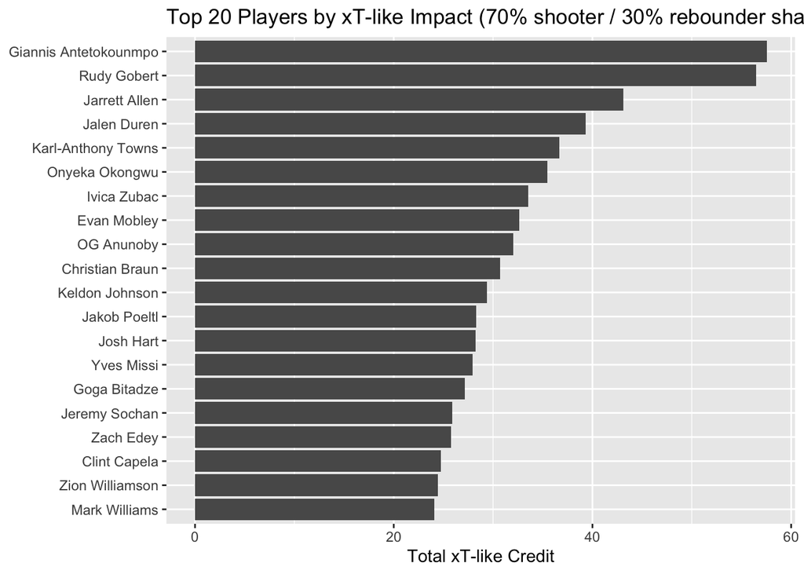

```r
ggplot2::ggplot(top20_shared, ggplot2::aes(reorder(player, xt_credit_total), xt_credit_total)) +
  ggplot2::geom_col() +
  ggplot2::coord_flip() +
  ggplot2::labs(
    title = "Top 20 Players by xT-like Impact (70% shooter / 30% rebounder share)",
    x = NULL, y = "Total xT-like Credit"
  )
```